# Analyse GEO Samples for contamination

```
# tissue migration
```

Now, detect samples we defined as contamined: * highly siginificant BioQC scores (min score per sample >6) * signature outside ‘expected’ signature that is at least 6 higher than the highest score in expected signatures. * (outlier in study)

We can find contamined studies with SQL only. To speed up things, we create a temporary table (rather a materialized view, but that’s not available on our old postgres server) filtering for samples, where a non-expected signature exceeds all expected signatures by a certain threshold (BioQC score > 6, aka. ‘enrichment-ratio’). This table is created in `db/queries/mk-extended_bioqc_res_table2.sql`.

We create a view `contamined_samples` that contains all contamined samples in `db/queries/get_contamined_samples.sql`.

Second, we retrieve the information we need for the migration chart from that temporary table.

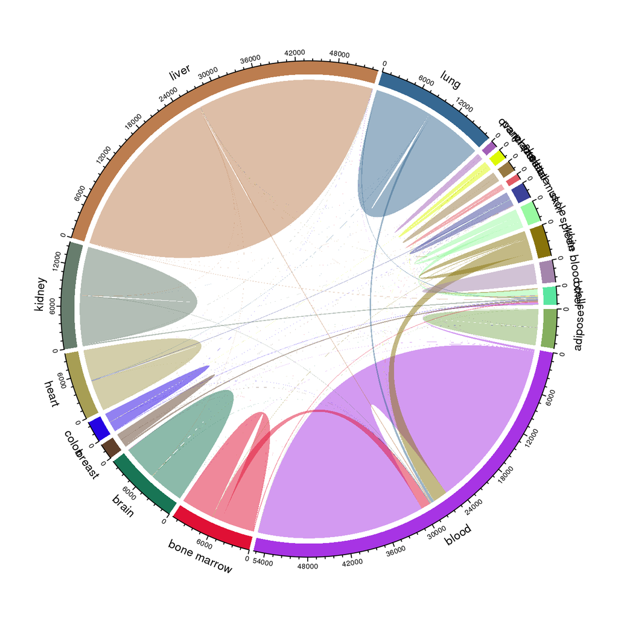

```r
query = "
select origin
     , destination
     , count(gsm) as \"count\"
from bioqc_tissue_migration
where rk = 1 -- in case of multi destination only take the highest enrichment_ratio.
group by origin, destination
order by origin, destination"
migration = dbGetQuery(mydb, query)
chordDiagram(migration)
```

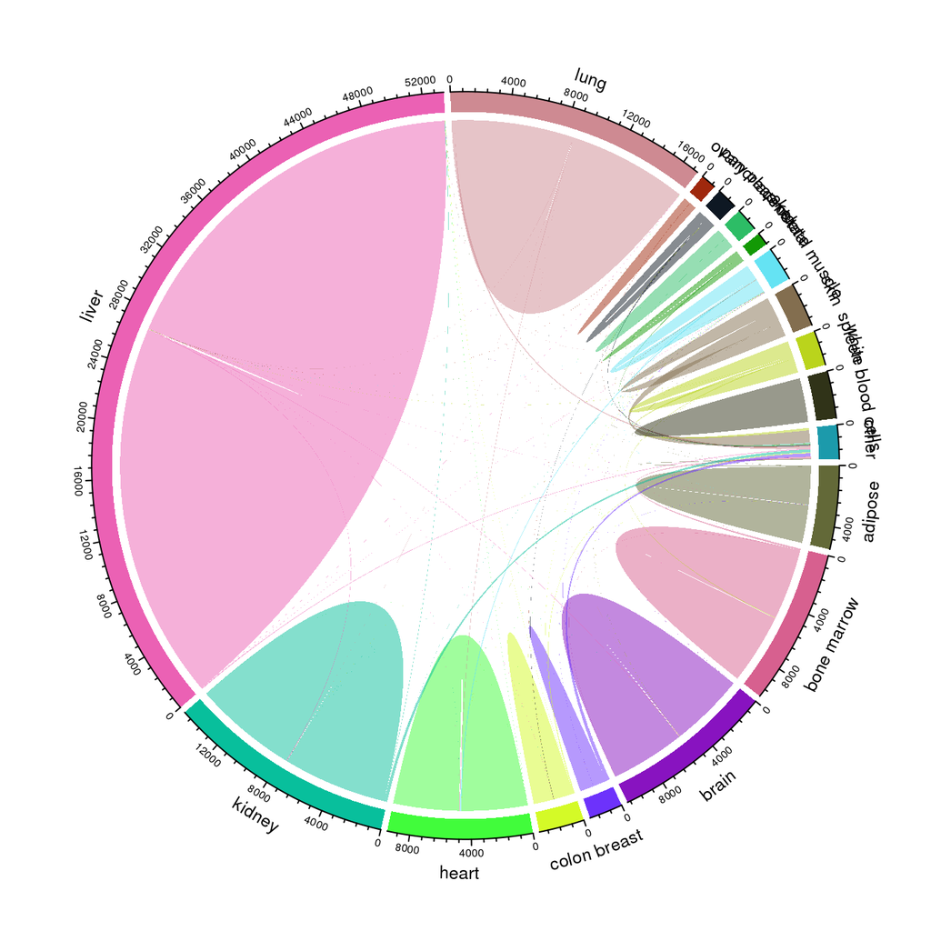

```r
chordDiagram(migration[migration$ORIGIN != 'blood' & migration$DESTINATION!='blood',])
```

Contamination in total:

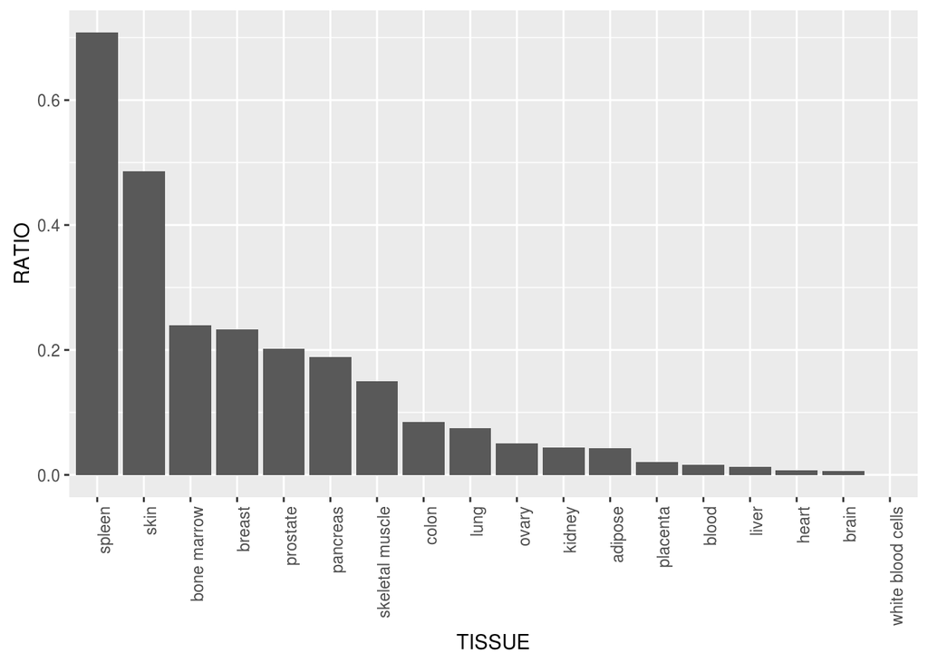

```r
byTissue = "
select tissue
     , count(gsm) as total
     , count(is_contam) as total
     , count(is_contam)/cast(count(gsm) as float) as ratio
from bioqc_contam_stats
group by tissue
order by ratio desc
"

tissue = data.table(dbGetQuery(mydb, byTissue))
tissue[,TISSUE:=factor(TISSUE, levels=TISSUE)]
ggplot(data=tissue, aes(x=TISSUE, y=RATIO)) +
  geom_bar(stat="identity") +
  theme(axis.text.x = element_text(angle = 90, hjust = 1))
```

We can also compose statistics about the origin of samples

By time

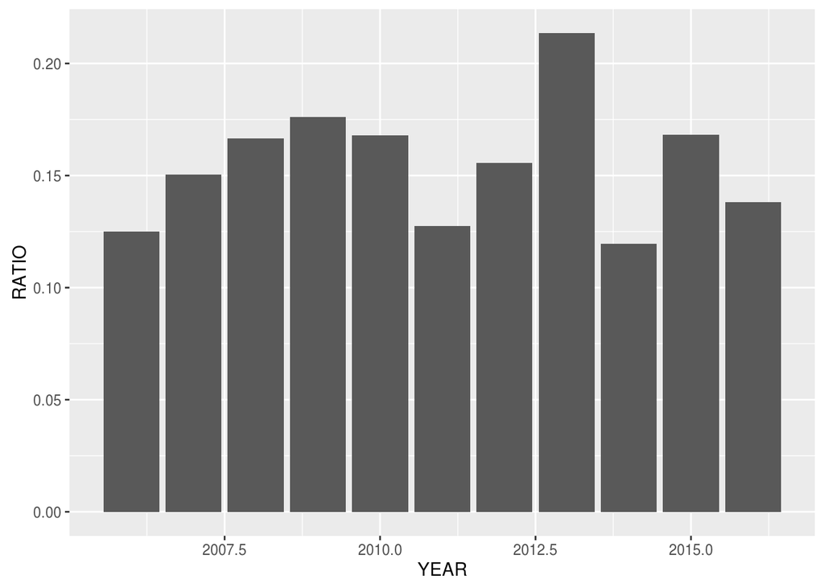

```r
byYear = "
select year
     , tissue
     , count(gsm) as total
     , count(is_contam) as total
     , count(is_contam)/cast(count(gsm) as float) as ratio
from bioqc_contam_stats
group by year, tissue
order by year, tissue
"

year = dbGetQuery(mydb, byYear)
tissues = c("adipose")
year.2 = year[year$TISSUE %in% tissues,]

ggplot(data=year, aes(x=YEAR, y=RATIO)) + stat_summary(fun.y="mean", geom="bar")
```

By country (that’s nice figures, but it’s not very representative… tissue-bias, statistical significance, …)

```r
byCountry = "
select country
     , tissue
     , count(gsm) as total
     , count(is_contam) as total
     , count(is_contam)/cast(count(gsm) as float) as ratio
from bioqc_contam_stats
group by country, tissue
order by country, tissue
"

country = dbGetQuery(mydb, byCountry)
country.2 = country[country$TISSUE == 'liver',]
#country.2 = ddply(country[country$total > 2000,], ~country,summarise,ratio=mean(ratio))

spdf <- joinCountryData2Map(country.2, joinCode="NAME", nameJoinColumn="COUNTRY")
```

```
## 33 codes from your data successfully matched countries in the map
## 0 codes from your data failed to match with a country code in the map
## 210 codes from the map weren't represented in your data
```

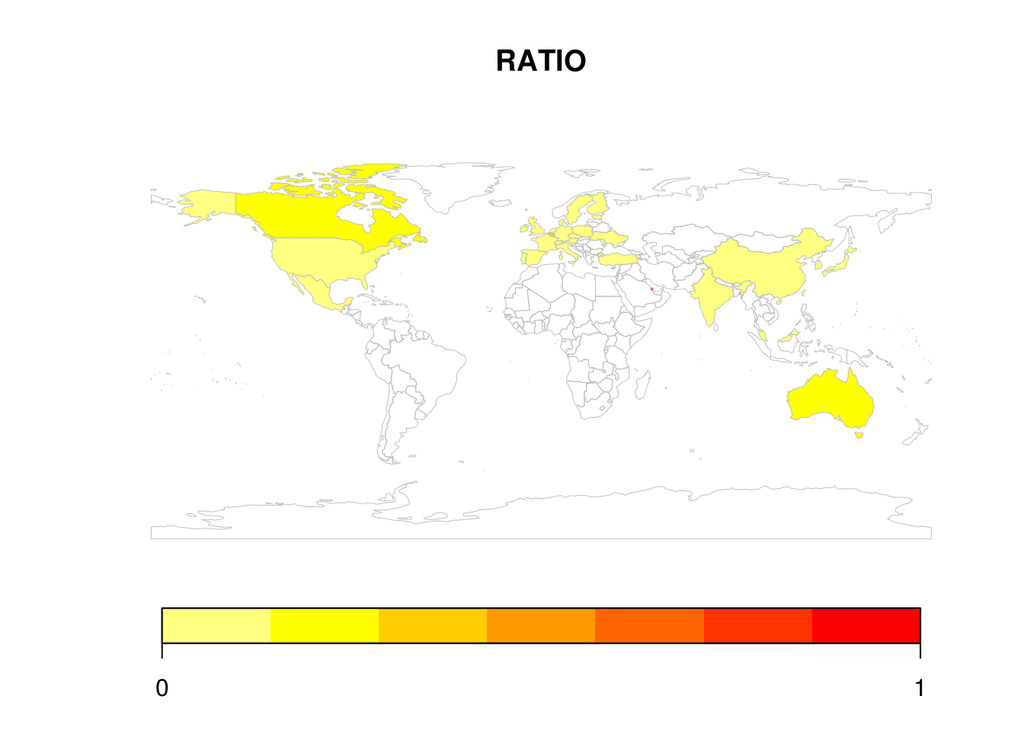

```r
mapCountryData(spdf, nameColumnToPlot="RATIO", catMethod="fixedWidth")
```

By organism

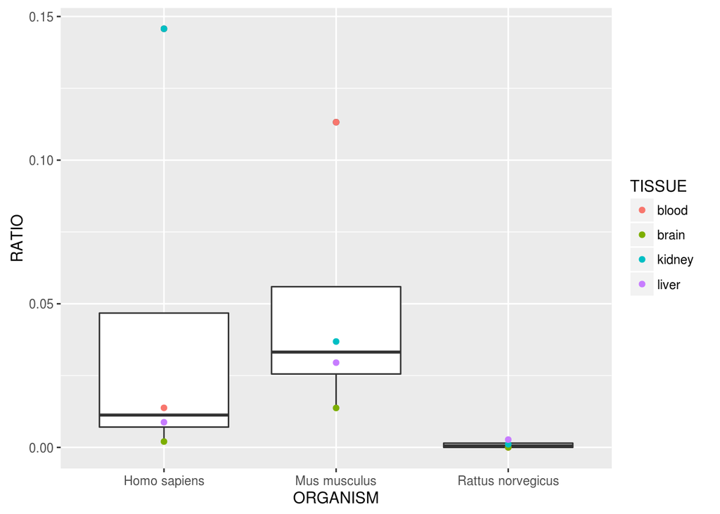

```r
byOrganism = "
select organism
     , tissue
     , count(gsm) as total
     , count(is_contam) as total
     , count(is_contam)/cast(count(gsm) as float) as ratio
from bioqc_contam_stats
group by organism, tissue
order by organism, tissue
"

organism = dbGetQuery(mydb, byOrganism)
tissues = c("blood", "brain", "kidney", "liver")
organism.2 = organism[organism$TISSUE %in% tissues, ]

#ggplot(data=organism.2, aes(x=ORGANISM, y=RATIO)) + stat_summary(fun.y="mean", geom="bar")
ggplot(data=organism.2, aes(x=ORGANISM, y=RATIO)) +
  geom_boxplot() +
  geom_point(aes(color=TISSUE))
```